# SentimentAnalysis_MelvinMathew

Mount the Drive

```python
from google.colab import drive
drive.mount('/content/drive')
```

## Data Description:

A sentiment analysis job about the problems of each major U.S. airline. Twitter data was scraped from February of 2015 and contributors were asked to first classify positive, negative, and neutral tweets, followed by categorizing negative reasons (such as "late flight" or "rude service").

## Dataset:

The dataset has the following columns:

- tweet_id
- airline_sentiment
- airline_sentiment_confidence
- negativereason
- negativereason_confidence
- airline
- airline_sentiment_gold
- name
- negativereason_gold
- retweet_count
- text
- tweet_coord
- tweet_created
- tweet_location
- user_timezone

## Objective:

To implement the techniques learned as a part of the course.

## View & Opinion

- When looking into a sentiments analysis problem we need to make sure that all the data pre-processing doesnt affect the meaning of the sentence and we can accurately identify the sentiment trying to be convied .
- Using sentiments analysis companies can learn how to improve and effectively implement strategies so as to increase customer base ans ensure returning customers

Importing the Libraries

```python
!pip install contractions

import re, string, unicodedata                          # Import Regex, string and unicodedata.
import contractions                                     # Import contractions library.
from bs4 import BeautifulSoup                           # Import BeautifulSoup.

import numpy as np                                      # Import numpy.
import pandas as pd                                     # Import pandas.
import nltk                                             # Import Natural Language Tool-Kit.

nltk.download('stopwords')                              # Downloading Stopwords.
nltk.download('punkt')
nltk.download('wordnet')

from nltk.corpus import stopwords                       # Import stopwords.
from nltk.tokenize import word_tokenize, sent_tokenize  # Import Tokenizer.
from nltk.stem.wordnet import WordNetLemmatizer         # Import Lemmatizer. For removing stem words
import unicodedata
```

```python
import os
directory= r'/content/drive/MyDrive/Colab Notebooks'
os.chdir(directory)
```

```python
# Loading data into pandas dataframe
data = pd.read_csv("Tweets.csv")
```

```python
data1=data.copy() # making a copy of the dataset
```

```python
data1.head() # printing the first 5 values of the dataset
```

|  | tweet_id | airline_sentiment | airline_sentiment_confidence | negativereason | negativereason_confidence | airline | airline_sentiment_gold | name | negativereason_gold | retweet_count | text | tweet_coord | tweet_created | tweet_location | user_timezone |
| --- | --- | --- | --- | --- | --- | --- | --- | --- | --- | --- | --- | --- | --- | --- | --- |
| 0 | 570306133677760513 | neutral | 1.0000 | NaN | NaN | Virgin America | NaN | cairdin | NaN | 0 | @VirginAmerica What @dhepburn said. | NaN | 2015-02-24 11:35:52 -0800 | NaN | Eastern Time (US & Canada) |
| 1 | 570301130888122368 | positive | 0.3486 | NaN | 0.0000 | Virgin America | NaN | jnardino | NaN | 0 | @VirginAmerica plus you've added commercials t... | NaN | 2015-02-24 11:15:59 -0800 | NaN | Pacific Time (US & Canada) |
| 2 | 570301083672813571 | neutral | 0.6837 | NaN | NaN | Virgin America | NaN | yvonnalynn | NaN | 0 | @VirginAmerica I didn't today... Must mean I n... | NaN | 2015-02-24 11:15:48 -0800 | Lets Play | Central Time (US & Canada) |
| 3 | 570301031407624196 | negative | 1.0000 | Bad Flight | 0.7033 | Virgin America | NaN | jnardino | NaN | 0 | @VirginAmerica it's really aggressive to blast... | NaN | 2015-02-24 11:15:36 -0800 | NaN | Pacific Time (US & Canada) |
| 4 | 570300817074462722 | negative | 1.0000 | Can't Tell | 1.0000 | Virgin America | NaN | jnardino | NaN | 0 | @VirginAmerica and it's a really big bad thing... | NaN | 2015-02-24 11:14:45 -0800 | NaN | Pacific Time (US & Canada) |

```python
data1.shape # printing the shape of the dataset
```

```
(14640, 15)
```

```python
data1.isnull().sum()*0.0068306  # finding the percentage of the null values
```

```
tweet_id                         0.000000
airline_sentiment                0.000000
airline_sentiment_confidence     0.000000
negativereason                  37.308737
negativereason_confidence       28.128411
airline                          0.000000
airline_sentiment_gold          99.726760
name                             0.000000
negativereason_gold             99.781405
retweet_count                    0.000000
text                             0.000000
tweet_coord                     93.039603
tweet_created                    0.000000
tweet_location                  32.329230
user_timezone                   32.923492
dtype: float64
```

```python
# dropping all the columns that have a majority of null values
data1.drop(["airline_sentiment_gold"],axis=1,inplace=True)
data1.drop(["negativereason_gold"],axis=1,inplace=True)
data1.drop(["tweet_coord"],axis=1,inplace=True)
```

```python
data1.head() # printing the first 5 rows
```

|  | tweet_id | airline_sentiment | airline_sentiment_confidence | negativereason | negativereason_confidence | airline | name | retweet_count | text | tweet_created | tweet_location | user_timezone |
| --- | --- | --- | --- | --- | --- | --- | --- | --- | --- | --- | --- | --- |
| 0 | 570306133677760513 | neutral | 1.0000 | NaN | NaN | Virgin America | cairdin | 0 | @VirginAmerica What @dhepburn said. | 2015-02-24 11:35:52 -0800 | NaN | Eastern Time (US & Canada) |
| 1 | 570301130888122368 | positive | 0.3486 | NaN | 0.0000 | Virgin America | jnardino | 0 | @VirginAmerica plus you've added commercials t... | 2015-02-24 11:15:59 -0800 | NaN | Pacific Time (US & Canada) |
| 2 | 570301083672813571 | neutral | 0.6837 | NaN | NaN | Virgin America | yvonnalynn | 0 | @VirginAmerica I didn't today... Must mean I n... | 2015-02-24 11:15:48 -0800 | Lets Play | Central Time (US & Canada) |
| 3 | 570301031407624196 | negative | 1.0000 | Bad Flight | 0.7033 | Virgin America | jnardino | 0 | @VirginAmerica it's really aggressive to blast... | 2015-02-24 11:15:36 -0800 | NaN | Pacific Time (US & Canada) |
| 4 | 570300817074462722 | negative | 1.0000 | Can't Tell | 1.0000 | Virgin America | jnardino | 0 | @VirginAmerica and it's a really big bad thing... | 2015-02-24 11:14:45 -0800 | NaN | Pacific Time (US & Canada) |

```python
data1.info() # printing the information on the columns i.e the number of null values and data types
```

```
<class 'pandas.core.frame.DataFrame'>
RangeIndex: 14640 entries, 0 to 14639
Data columns (total 12 columns):
 #   Column                        Non-Null Count  Dtype
---  ------                        --------------  -----
 0   tweet_id                      14640 non-null  int64
 1   airline_sentiment             14640 non-null  object
 2   airline_sentiment_confidence  14640 non-null  float64
 3   negativereason                9178 non-null   object
 4   negativereason_confidence     10522 non-null  float64
 5   airline                       14640 non-null  object
 6   name                          14640 non-null  object
 7   retweet_count                 14640 non-null  int64
 8   text                          14640 non-null  object
 9   tweet_created                 14640 non-null  object
 10  tweet_location                9907 non-null   object
 11  user_timezone                 9820 non-null   object
dtypes: float64(2), int64(2), object(8)
memory usage: 1.3+ MB
```

```python
# finding the number of negative,neutral and positive sentiments for each airline
data1.groupby(['airline', 'airline_sentiment']).airline_sentiment.count()
```

```
airline         airline_sentiment
American        negative             1960
                neutral               463
                positive              336
Delta           negative              955
                neutral               723
                positive              544
Southwest       negative             1186
                neutral               664
                positive              570
US Airways      negative             2263
                neutral               381
                positive              269
United          negative             2633
                neutral               697
                positive              492
Virgin America  negative              181
                neutral               171
                positive              152
Name: airline_sentiment, dtype: int64
```

```python
# Function to create barplots that indicate percentage for each category.
import seaborn as sns
import matplotlib.pyplot as plt
def perc_on_bar(z):

    total = len(data1[z]) # length of the column
    plt.figure(figsize=(15,5))
    ax = sns.countplot(data1[z],palette='Paired')
    for p in ax.patches:
        percentage = '{:.1f}%'.format(100 * p.get_height()/total) # percentage of each class of the category
        x = p.get_x() + p.get_width() / 2 - 0.05 # width of the plot
        y = p.get_y() + p.get_height()           # hieght of the plot

        ax.annotate(percentage, (x, y), size = 12) # annotate the percantage
    plt.show() # show the plot
```

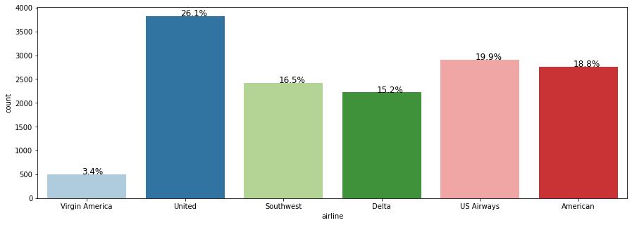

```python
perc_on_bar('airline') # finding out the percentage of the  different airlines appearing in the dataset
```

- We see that United is the most frequent airline with 26.1% followed by US Airways at 19.9%
- Virgin America is the least occuring airline with only 3.4%

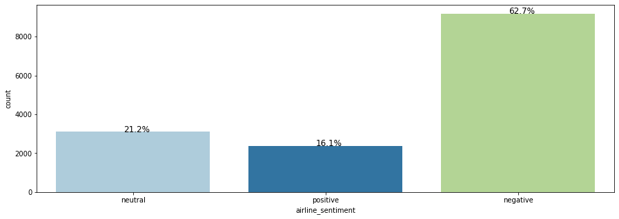

```python
perc_on_bar('airline_sentiment') # finding the percentage of the sentiments in the dataset
```

- Majority of the comments are negative at 62.7%
- Postive comments are the least with only 16.1%

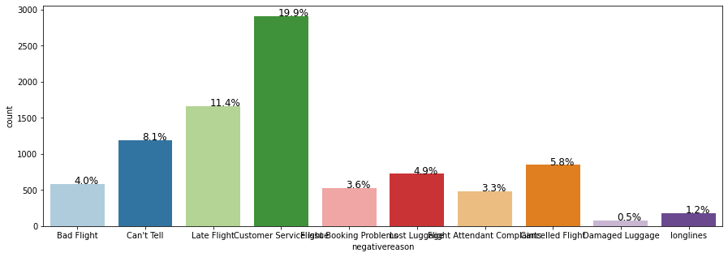

```python
perc_on_bar('negativereason')
```

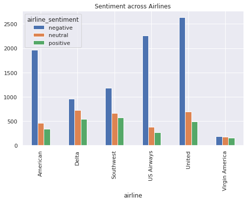

```python
sns.set(color_codes=True)

airline_sentiment =  data.groupby(['airline', 'airline_sentiment']).airline_sentiment.count().unstack();

airline_sentiment.plot(kind='bar', figsize=(8,5), title="Sentiment across Airlines");
```

- Negative comments are a majority in United and US airways
- Positive comments are a highest in Southwest and Delta airlines
- Virgin america doesnt have much difference in their Positive and Negative sentiments

```python
from wordcloud import WordCloud, STOPWORDS
airline_tweets=data1[data1['airline_sentiment']=='negative'] # Extracting the Negative sentiments


words = ' '.join(airline_tweets['text']) # creating a complete sentence from all the documents in the corpus


cleaned_word = " ".join([word for word in words.split() # splitting the sentence into words and removing the http ,@ and RT
                            if 'http' not in word
                                and not word.startswith('@')
                                and word != 'RT'
                            ])

wordcloud_neg = WordCloud(stopwords=STOPWORDS, # Creating the wordcloud for the negative sentiments
                      background_color='black',
                      width=3000,
                      height=2500
                     ).generate(cleaned_word)

airline_tweets=data[data['airline_sentiment']=='positive'] # extracting the positive sentiments

words = ' '.join(airline_tweets['text']) # creating a complete sentence from all the documents in the corpus

cleaned_word = " ".join([word for word in words.split() # splitting the sentence into words and removing the http, @ and RT
                            if 'http' not in word
                                and not word.startswith('@')
                                and word != 'RT'
                            ])

wordcloud_pos = WordCloud(stopwords=STOPWORDS, # creating a word cloud for the positive sentiments
                      background_color='black',
                      width=3000,
                      height=2500
                     ).generate(cleaned_word)
```

```python
cleaned_word # printing out the cleaned words
```

[output not shown]

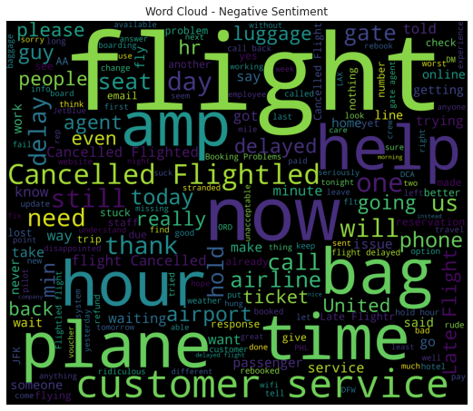

```python
# Plotting the negative sentiments word cloud
plt.figure(figsize=(20, 14));

plt.subplot(1,2,1);

plt.title("Word Cloud - Negative Sentiment");

plt.imshow(wordcloud_neg);

plt.axis('off');
```

- Flight, help ,cancelled , plane and time are prominent words in the word cloud that could suggest that there are alot of complaints on cencelled or delayed flights causing long waiting periods , customers require an added help to be provided & the customer service needs to be bettered

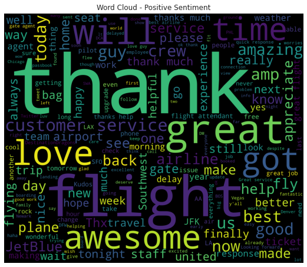

```python
# Plotting the positive sentiments word cloud
plt.figure(figsize=(20, 14));

plt.subplot(1,2,2);

plt.title("Word Cloud - Positive Sentiment");

plt.imshow(wordcloud_pos);

plt.axis('off');
```

- Thank , great ,flight ,awesome and love are prominent words in the word cloud suggesting that the customers had a good experience while flying .

Dropping all the columns except text and airline sentimnts

```python
data1=data1[['text','airline_sentiment']]
```

```python
data1.shape # printing the shape of the dataset
```

```
(14640, 2)
```

```python
data1.head() # printing the first 5 values of the dataset
```

|  | text | airline_sentiment |
| --- | --- | --- |
| 0 | @VirginAmerica What @dhepburn said. | neutral |
| 1 | @VirginAmerica plus you've added commercials t... | positive |
| 2 | @VirginAmerica I didn't today... Must mean I n... | neutral |
| 3 | @VirginAmerica it's really aggressive to blast... | negative |
| 4 | @VirginAmerica and it's a really big bad thing... | negative |

```python
data1['airline_sentiment'].value_counts() # printing the count of the negative , neutral and positive sentiments
```

```
negative    9178
neutral     3099
positive    2363
Name: airline_sentiment, dtype: int64
```

Removing HTML Tags

```python
# Function to remove the HTML tags
def strip_html(text):
    soup = BeautifulSoup(text, "html.parser")
    return soup.get_text()

data1['text'] = data1['text'].apply(lambda x: strip_html(x))
data1.head() # printing the first 5 values of the dataset
```

|  | text | airline_sentiment |
| --- | --- | --- |
| 0 | @VirginAmerica What @dhepburn said. | neutral |
| 1 | @VirginAmerica plus you've added commercials t... | positive |
| 2 | @VirginAmerica I didn't today... Must mean I n... | neutral |
| 3 | @VirginAmerica it's really aggressive to blast... | negative |
| 4 | @VirginAmerica and it's a really big bad thing... | negative |

```python
for i, row in data.iterrows():
    clean_text = re.sub(r"http\S+", "", data1.at[i, 'text']) #Extracting anything that follows http till a space is encountered
    clean_text = re.sub(r"https",'',clean_text)
    data1.at[i,'text'] = clean_text
data1.head() # printing the first 5 values of the dataset
```

|  | text | airline_sentiment |
| --- | --- | --- |
| 0 | @VirginAmerica What @dhepburn said. | neutral |
| 1 | @VirginAmerica plus you've added commercials t... | positive |
| 2 | @VirginAmerica I didn't today... Must mean I n... | neutral |
| 3 | @VirginAmerica it's really aggressive to blast... | negative |
| 4 | @VirginAmerica and it's a really big bad thing... | negative |

Removing Accented Characters

```python
!pip install unidecode

import unidecode

# Function to remove all the accented charachters and make them into regular alphabets
def remove_accented_chars(text):



    text = unidecode.unidecode(text)

    return text

data1['text'] = data1['text'].apply(lambda x: remove_accented_chars(x))
data1.head() # Printing the first 5 values of the dataset
```

|  | text | airline_sentiment |
| --- | --- | --- |
| 0 | @VirginAmerica What @dhepburn said. | neutral |
| 1 | @VirginAmerica plus you've added commercials t... | positive |
| 2 | @VirginAmerica I didn't today... Must mean I n... | neutral |
| 3 | @VirginAmerica it's really aggressive to blast... | negative |
| 4 | @VirginAmerica and it's a really big bad thing... | negative |

Removing Contractions

```python
# Function to replace the contradictions
def replace_contractions(text):
    """Replace contractions in string of text"""
    return contractions.fix(text)

data1['text'] = data1['text'].apply(lambda x: replace_contractions(x))
data1.head() # printing the first 5 values of the data set
```

|  | text | airline_sentiment |
| --- | --- | --- |
| 0 | @VirginAmerica What @dhepburn said. | neutral |
| 1 | @VirginAmerica plus you have added commercials... | positive |
| 2 | @VirginAmerica I did not today... Must mean I ... | neutral |
| 3 | @VirginAmerica it is really aggressive to blas... | negative |
| 4 | @VirginAmerica and it is a really big bad thin... | negative |

- We see that you've has turned to you have and didn't has turned to did not

Removing Numbers

```python
# Function to remove the numbers
def remove_numbers(text):
  text = re.sub(r'\d+', '', text)
  return text

data1['text'] = data1['text'].apply(lambda x: remove_numbers(x))
data1.head() # printing the first 5 values of the dataset
```

|  | text | airline_sentiment |
| --- | --- | --- |
| 0 | @VirginAmerica What @dhepburn said. | neutral |
| 1 | @VirginAmerica plus you have added commercials... | positive |
| 2 | @VirginAmerica I did not today... Must mean I ... | neutral |
| 3 | @VirginAmerica it is really aggressive to blas... | negative |
| 4 | @VirginAmerica and it is a really big bad thin... | negative |

Tokenizing

```python
from nltk.tokenize import TweetTokenizer

 # Function to tokenize the words
tknzr=TweetTokenizer() # using tknzr as tweet tokenizer

data1['text'] = data1.apply(lambda row: tknzr.tokenize(row['text']), axis=1) # Tokenization of data

data1.head() # printing the first 5 values of the dataset
```

|  | text | airline_sentiment |
| --- | --- | --- |
| 0 | [@VirginAmerica, What, @dhepburn, said, .] | neutral |
| 1 | [@VirginAmerica, plus, you, have, added, comme... | positive |
| 2 | [@VirginAmerica, I, did, not, today, ..., Must... | neutral |
| 3 | [@VirginAmerica, it, is, really, aggressive, t... | negative |
| 4 | [@VirginAmerica, and, it, is, a, really, big, ... | negative |

- all the words have been converted to tokens

StopWords

```python
from nltk.corpus import stopwords
stopwords = stopwords.words('english') # assigning the stopwards as english stopwords
stopwords # printing the stopwords
```

```
['i',
 'me',
 'my',
 'myself',
 'we',
 'our',
 'ours',
 'ourselves',
 'you',
 "you're",
 "you've",
 "you'll",
 "you'd",
 'your',
 'yours',
 'yourself',
 'yourselves',
 'he',
 'him',
 'his',
 'himself',
 'she',
 "she's",
 'her',
 'hers',
 'herself',
 'it',
 "it's",
 'its',
 'itself',
 'they',
 'them',
 'their',
 'theirs',
 'themselves',
 'what',
 'which',
 'who',
 'whom',
 'this',
```

[output cut: 124 more lines]

```
 "mustn't",
 'needn',
 "needn't",
 'shan',
 "shan't",
 'shouldn',
 "shouldn't",
 'wasn',
 "wasn't",
 'weren',
 "weren't",
 'won',
 "won't",
 'wouldn',
 "wouldn't"]
```

since there are negations which add meaning to the sentence we need to retain them to maintain the meaining of the sentence

```python
negations=['ain','aren',"aren't",'couldn',"couldn't",'didn',"didn't",'doesn',"doesn't",'hadn',"hadn't",'hasn',"hasn't",'haven',"haven't",'isn',"isn't",'mightn',"mightn't",'mustn',"mustn't",'needn',"needn't",'shan',"shan't",'shouldn',"shouldn't",'wasn',"wasn't",'weren',"weren't",'won',"won't",'wouldn', "wouldn't"]

stopwords = list(set(stopwords) - set(negations))  # removing the negations from the list of stopwords
```

Lemmetization

```python
lemmatizer = WordNetLemmatizer() # asigning the word net lemmatizer as the lemmatizer

def remove_non_ascii(words): #Removing non-ASCII characters from list of tokenized words
    new_words = []
    for word in words:
        new_word = unicodedata.normalize('NFKD', word).encode('ascii', 'ignore').decode('utf-8', 'ignore')
        new_words.append(new_word)
    return new_words

def to_lowercase(words): #Converting all characters to lowercase from list of tokenized words
    new_words = []
    for word in words:
        new_word = word.lower()
        new_words.append(new_word)
    return new_words

def remove_punctuation(words): #Removing punctuation from list of tokenized words
    new_words = []
    for word in words:
        new_word = re.sub(r'[^\w\s]', '', word)
        if new_word != '':
            new_words.append(new_word)
    return new_words

def remove_stopwords(words): #Removing stop words from list of tokenized words
    new_words = []
    for word in words:
        if word not in stopwords:
            new_words.append(word)
    return new_words

def lemmatize_list(words): # Lemmatizing the words
    new_words = []
    for word in words:
      new_words.append(lemmatizer.lemmatize(word, pos='v'))
    return new_words

def normalize(words): # normalizing the words
    words = remove_non_ascii(words)
    words = to_lowercase(words)
    words = remove_punctuation(words)
    words = remove_stopwords(words)
    words = lemmatize_list(words)
    return ' '.join(words)

data1['text'] = data1.apply(lambda row: normalize(row['text']), axis=1)
data1.head() # printing the first 5 values of the dataset
```

|  | text | airline_sentiment |
| --- | --- | --- |
| 0 | virginamerica dhepburn say | neutral |
| 1 | virginamerica plus add commercials experience ... | positive |
| 2 | virginamerica today must mean need take anothe... | neutral |
| 3 | virginamerica really aggressive blast obnoxiou... | negative |
| 4 | virginamerica really big bad thing | negative |

- All the @,stopwords,punctuations have been removed all the values have been made into lowercase letters
- The data has been pre-processed and can be fed into the models

CountVectorizer

```python
# Vectorization (Convert text data to numbers).
from sklearn.feature_extraction.text import CountVectorizer

vectorizer = CountVectorizer(max_features=10000)                # Keep only 10000 features as number of features
features = vectorizer.fit_transform(data1['text'])

features = features.toarray()
```

```python
vectorizer.vocabulary_ # printing the count of each word
```

[output not shown]

[output cut: 946 more lines]

```
 'battle': 873,
 'cancer': 1400,
 'freyasfund': 3661,
 'biztravel': 1031,
 'less': 4721,
 'half': 3973,
 'price': 6737,
 'round': 7394,
 'stun': 8314,
 'dtw': 2813,
 'sell': 7663,
 'promo': 6810,
 'ssal': 8156,
 'momma': 5422,
 ...}
```

```python
features.shape # printing the shapes of the features
```

```
(14640, 10000)
```

```python
x = features #Independent variable

y = data1.airline_sentiment # dependent variable
```

```python
from sklearn.model_selection import StratifiedKFold
```

Spliting data into training and testing set

```python
# Split data into training and testing set.

from sklearn.model_selection import train_test_split

x_train, x_test, y_train, y_test = train_test_split(x, y, test_size=0.3, random_state=42)
```

```python
from sklearn.tree import DecisionTreeClassifier
from sklearn.ensemble import RandomForestClassifier
from sklearn.ensemble import BaggingClassifier
from sklearn.ensemble import AdaBoostClassifier
from sklearn.ensemble import GradientBoostingClassifier
from sklearn.model_selection import cross_val_score



from sklearn.metrics import accuracy_score, f1_score, recall_score, precision_score, confusion_matrix


import numpy as np
```

Building the Models

```python
model_dt = DecisionTreeClassifier(criterion='entropy', random_state=22)

model_rf = RandomForestClassifier(max_samples=0.8, random_state=42)

model_bg = BaggingClassifier(bootstrap=True, random_state=22)
```

```python
models=[ model_dt, model_rf, model_bg]
```

```python
modelname =['Decision Tree','Random Forest','Bagging']
```

```python
model_name=[]
technique_type=[]
train_score=[]
test_score=[]
cv_min=[]
cv_max=[]
cv_av=[]
cv_std=[]
std_score=[]

i=0
for m in models:

    m.fit(x_train, y_train)

    print(modelname[i])

    model_name.append(modelname[i])
    i+=1

    train_score.append(m.score(x_train,y_train))
    test_score.append(m.score(x_test,y_test))

    sf=StratifiedKFold(n_splits=5, random_state=20, shuffle=True)
    kf=cross_val_score(m, x_train, y_train, cv=sf)

    cv_min.append(np.min(kf))
    cv_max.append(np.max(kf))
    cv_av.append(np.mean(kf))
    cv_std.append(np.std(kf))
    technique_type.append('Count Vectorize')
```

```
Decision Tree
Random Forest
Bagging
```

```python
test_score # printing the scores of all the models
```

```
[0.7015027322404371, 0.7695810564663024, 0.7456739526411658]
```

```python
# Printing the metrics of the models
Results_Cv=pd.DataFrame()
Results_Cv['Model']=modelname
Results_Cv['Technique']=technique_type
Results_Cv['Train Acc']=train_score
Results_Cv['Cross Val - Min Accuarcy']=cv_min
Results_Cv['Cross Val - Avg Accuarcy']=cv_av
Results_Cv['Cross Val - Max Accuarcy']=cv_max
Results_Cv['Cross Val - Std of Accuarcy']=cv_std
Results_Cv['Test']=test_score
Results_Cv
```

|  | Model | Technique | Train Acc | Cross Val - Min Accuarcy | Cross Val - Avg Accuarcy | Cross Val - Max Accuarcy | Cross Val - Std of Accuarcy | Test |
| --- | --- | --- | --- | --- | --- | --- | --- | --- |
| 0 | Decision Tree | Count Vectorize | 0.994828 | 0.676916 | 0.684620 | 0.693171 | 0.005445 | 0.701503 |
| 1 | Random Forest | Count Vectorize | 0.994340 | 0.746218 | 0.753805 | 0.759512 | 0.004534 | 0.769581 |
| 2 | Bagging | Count Vectorize | 0.973068 | 0.707317 | 0.717799 | 0.724744 | 0.006025 | 0.745674 |

- Random Forest with count-vectorizer is giving us the best accuracy on the test set i.e 76.95%

Confusion Matrix

```
[[2571  176   67]
 [ 409  403   72]
 [ 198   90  406]]
```

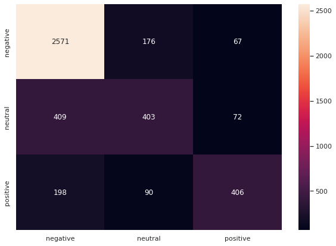

```python
# Print and plot Confusion matirx to get an idea of how the distribution of the prediction is, among all the classes.

import matplotlib.pyplot as plt
import seaborn as sns
from sklearn.metrics import confusion_matrix

result=model_rf.predict(x_test)

conf_mat = confusion_matrix(y_test, result)

print(conf_mat)

df_cm = pd.DataFrame(conf_mat, index = [i for i in ['negative', 'neutral','positive']],
                  columns = [i for i in ['negative', 'neutral','positive']])
plt.figure(figsize = (10,7))
sns.heatmap(df_cm, annot=True, fmt='g')
```

- 3380 values of sentiments have been correctly classified

Word Cloud

```
thank,great,jetblue,usairways,flight,delay,unite,southwestair,love,hours,cancel,americanair,hold,virginamerica,get,bag,wait,call,service,awesome,dm,time,hour,follow,amaze,cannot,help,still,please,customer,fleek,best,fly,go,try,make,say,would,need,tell,
```

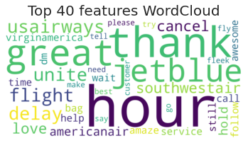

```python
all_features =vectorizer.get_feature_names()              #Instantiate the feature from the vectorizer
top_features=''                                            # Addition of top 40 feature into top_feature after training the model
feat=model_rf.feature_importances_
features=np.argsort(feat)[::-1]
for i in features[0:40]:
    top_features+=all_features[i]
    top_features+=','

print(top_features)

print(" ")
print(" ")

from wordcloud import WordCloud
wordcloud = WordCloud(background_color="white",colormap='viridis',width=2000,
                          height=1000).generate(top_features)

# Display the generated image:
plt.imshow(wordcloud, interpolation='bilinear')
plt.figure(1, figsize=(20, 11), frameon='equal')
plt.title('Top 40 features WordCloud', fontsize=20)
plt.axis("off")
plt.show()
```

- Thank,greatness,jetblue,usairways and flight are the top features for the random forest classifier
- make, say,would,need and tell are the bottom features of the random forest classifer

Tf-idf

```python
# Using TfidfVectorizer to convert text data to numbers.

from sklearn.feature_extraction.text import TfidfVectorizer

vectorizer = TfidfVectorizer(max_features=10000)
data_features = vectorizer.fit_transform(data1['text'])

data_features = data_features.toarray()

data_features.shape
```

```
(14640, 10000)
```

```python
vectorizer.vocabulary_ # printing the count of the words
```

[output not shown]

[output cut: 946 more lines]

```
 'battle': 873,
 'cancer': 1400,
 'freyasfund': 3661,
 'biztravel': 1031,
 'less': 4721,
 'half': 3973,
 'price': 6737,
 'round': 7394,
 'stun': 8314,
 'dtw': 2813,
 'sell': 7663,
 'promo': 6810,
 'ssal': 8156,
 'momma': 5422,
 ...}
```

```python
X = data_features # independent vairable

y = data.airline_sentiment
```

Spliting the data into training and testing set

```python
X_train, X_test, y_train, y_test = train_test_split(X, y, test_size=0.3, random_state=42)
```

Building the models

```python
model_dt = DecisionTreeClassifier(criterion='entropy', random_state=42)
model_rf = RandomForestClassifier(max_samples=0.8, random_state=42)
model_bg = BaggingClassifier(bootstrap=True, random_state=22)
```

```python
models=[model_dt, model_rf, model_bg]
modelname=['Decision Tree','Random Forest','Bagging']
```

```python
model_name=[]
train_score=[]
test_score=[]
cv_min=[]
cv_max=[]
cv_av=[]
cv_std=[]
std_score=[]

i=0
for m in models:

    m.fit(X_train, y_train)

    print(modelname[i])

    model_name.append(modelname[i])
    i+=1

    train_score.append(m.score(X_train,y_train))
    test_score.append(m.score(X_test,y_test))

    sf=StratifiedKFold(n_splits=5, random_state=20, shuffle=True)
    kf=cross_val_score(m, X_train, y_train, cv=sf)



    cv_min.append(np.min(kf))
    cv_max.append(np.max(kf))
    cv_av.append(np.mean(kf))
    cv_std.append(np.std(kf))
```

```
Decision Tree
Random Forest
Bagging
```

```python
test_score # printing the test set scores
```

```
[0.6846539162112932, 0.7693533697632058, 0.7320127504553734]
```

```python
# printing all the metrics of the models
Results=pd.DataFrame()
Results['Model']=model_name
Results['Technique']='TF-IDF'
Results['Train Acc']=train_score
Results['Cross Val - Min Accuarcy']=cv_min
Results['Cross Val - Avg Accuarcy']=cv_av
Results['Cross Val - Max Accuarcy']=cv_max
Results['Cross Val - Std of Accuarcy']=cv_std
Results['Test']=test_score
Results
```

|  | Model | Technique | Train Acc | Cross Val - Min Accuarcy | Cross Val - Avg Accuarcy | Cross Val - Max Accuarcy | Cross Val - Std of Accuarcy | Test |
| --- | --- | --- | --- | --- | --- | --- | --- | --- |
| 0 | Decision Tree | TF-IDF | 0.994828 | 0.652513 | 0.667348 | 0.679512 | 0.009534 | 0.684654 |
| 1 | Random Forest | TF-IDF | 0.993852 | 0.744265 | 0.751171 | 0.757561 | 0.005033 | 0.769353 |
| 2 | Bagging | TF-IDF | 0.971116 | 0.705854 | 0.715750 | 0.720000 | 0.005191 | 0.732013 |

- Random Forest with Tf-idf is giving us the best accuracy on the test set i.e 76.93%

Condusion Matrix

```
[[2674  102   38]
 [ 504  330   50]
 [ 244   75  375]]
```

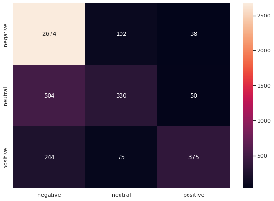

```python
result = model_rf.predict(X_test)
conf_mat = confusion_matrix(y_test, result)

print(conf_mat)

df_cm = pd.DataFrame(conf_mat, index = [i for i in ['negative', 'neutral','positive']],
                  columns = [i for i in ['negative', 'neutral','positive']])
plt.figure(figsize = (10,7))
sns.heatmap(df_cm, annot=True, fmt='g')
```

- 3,379 values of sentiments have been correctly classified

Word Cloud

```
thank,jetblue,southwestair,usairways,unite,great,americanair,flight,delay,love,virginamerica,cancel,hold,get,hours,awesome,dm,follow,bag,service,wait,call,please,amaze,time,fleek,fly,hour,cannot,help,customer,best,still,good,make,would,send,appreciate,much,need,
```

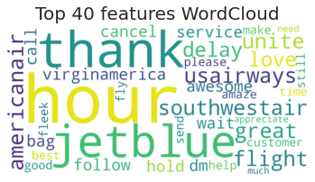

```python
all_features =vectorizer.get_feature_names()              #Instantiate the feature from the vectorizer
top_features=''                                            # Addition of top 40 feature into top_feature after training the model
feat=model_rf.feature_importances_
features=np.argsort(feat)[::-1]
for i in features[0:40]:
    top_features+=all_features[i]
    top_features+=','

print(top_features)

print(" ")
print(" ")

from wordcloud import WordCloud
wordcloud = WordCloud(background_color="white",colormap='viridis',width=2000,
                          height=1000).generate(top_features)

# Display the generated image:
plt.imshow(wordcloud, interpolation='bilinear')
plt.figure(1, figsize=(20, 11), frameon='equal')
plt.title('Top 40 features WordCloud', fontsize=20)
plt.axis("off")
plt.show()
```

- thank,jetblue,southwestair ,usairways and unite are the top features in the random forest classifier
- would ,send ,appreciate, much and needed are the bottom features of the random forest classifiers

## Summary

- We worked a dataset based on the sentiments of various problems in different US airlines .
- We looked into barplots for the various airlines and in what percentage they were appearing the dataset, sentiments and their percentages, and the negative reasons and their percentages
- We looked into the data and did various Pre-Processing techniques before feeding the data into the model i.e removing HTML tags,stopwords, removing accented characters , Tokenization etc.
- We used 2 vectorizers CountVectorizer and Tf-idf Vectorizer
- We build 3 models Decission Tree ,Random Forest and Bagging classifiers for both of the vectorizers
- We evaluated all the models and Random Forest on both of the vectorizers performed the best
- Random Forest with CountVectorizer is the suggested model as it gave a 76.95% on the test set and accurately classified 3380 sentiments out of 4392 total values .
- Thank,greatness,jetblue,usairways and flight were the top features for the model